# Praca domowa nr 5

Piotr Fic

6 grudnia 2019

## Dane wykorzystane w badaniu

Dane, które zostały przedstawione na wykresach są autentyczne i opisują strukturę rynku sprzedaży energii elektrycznej w Polsce. Na potrzeby ankiety i badania, przedstawiłem je na dwóch wykresach: słupkowym i kołowym. Nazwy firm zmieniłem na neutrealne, żeby ankietowani nie mogli odpowiadać na podstawie sowjej ewentualnej wiedzy na ten temat.

## Schemat badania

Link do ankiety: https://cutt.ly/qe8LpDm  
Formularz został wypełniony w większości przez osoby z wykształceniem średnim obecnie studujące, z grupy wiekowej 18-25 lat.  
Liczba odpowiedzi wyniosła 19.

Do wykresów przygotowałem dwa pytania:

- odczytanie wartości z wykresu
- porównanie dwóch wartości z prezentowanych na wykresie

Zadając pytania zmieniłem wartości, o których podanie prosiłem aby ankietowani nie udzielali odpowiedzi odczytując dane raz na pierwszym wykresie.

## Wykresy

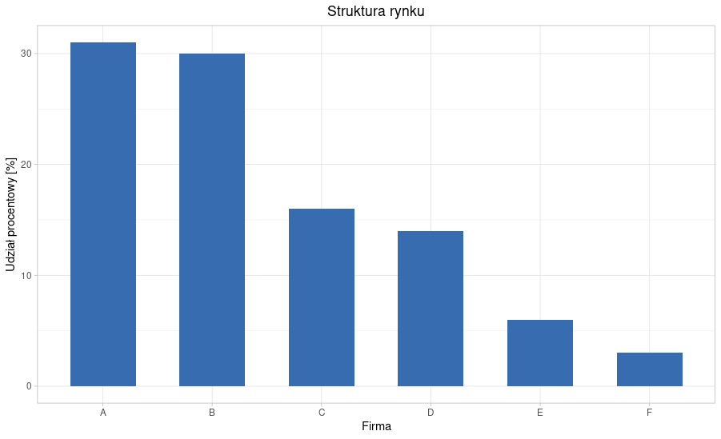

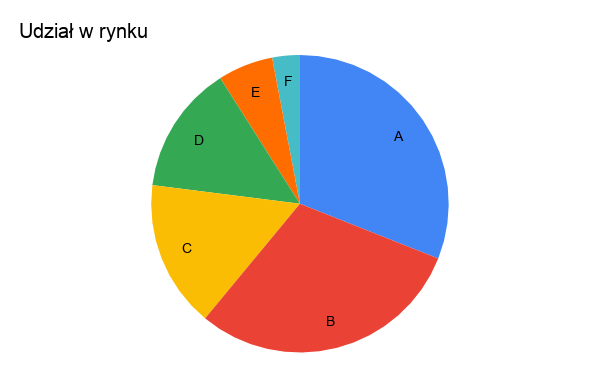

## Wyniki ankiety

Pytania:

- Wykres słupkowy: Podaj udział [%] w rynku firmy D.
- Wykres kolowy: Podaj udział [%] w rynku firmy B.
- Wykres słupkowy: Podaj o ile punktów procentowych różni się udział firm A oraz C.
- Wykres kolowy: Podaj o ile punktów procentowych różni się udział firm D oraz E.

Punkty w zielonym kolorze oznaczają poprawną odpowiedź.

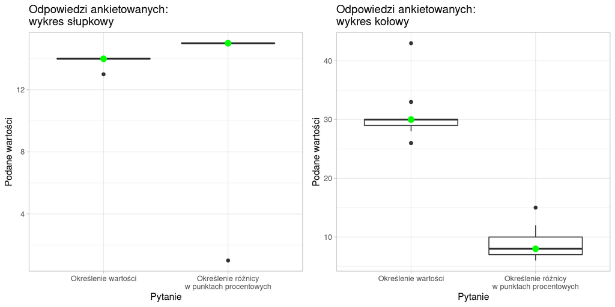

## Podsumowanie

Wykres słupkowy zapewnił ewidentnie dokładniejsze odczytanie danych przez ankietowanych. Badani odczytując dane z wykresu kołowego mylili się częściej, zwłasza kiedy pytanie wymagało porównania wielkości danych pomiędzy sobą. Poprawność odczytu  
i porównania danych z wykresu słupkowego była niemal 100%-owa.